# PHMX666 Communications Assignment 2

Jerry Hu

2025-07-26

# 1 Background and Summary

This population pharmacokinetic analysis was conducted to characterize the pharmacokinetics of [drug name] and identify clinically relevant covariates that influence drug exposure. The study included both healthy volunteers and patients with varying degrees of hepatic function to evaluate the impact of demographic and pathophysiological factors on drug disposition. The objective was to characaterize drug disopsotion and to begin quantifying relationships between patient characteristics and pharmacokinetic parameters to inform dosing recommendations for future clinical trials.

The final population pharmacokinetic model was a two-compartment model with first-order absorption that included covariate effects of ALT and hepatic status on clearance, age and weight on intercompartmental clearance, creatinine clearance on central volume, and weight and hepatic status on peripheral volume.

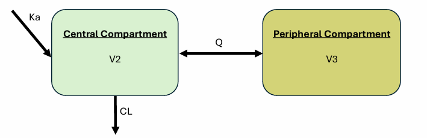

Model Schematic

```r
knitr::include_graphics("C:/Users/jerry/OneDrive/Documents/PMX/PHMX666 Communications/R Assignment/Schematic.png")
```

**RECOMMENDED NEXT STEPS**

- Conduct simulations to assess optimal PK sampling times and evaluate covariate effects on Cmax and AUC
- **Subjects with decreased hepatic function demonstrated lower clearance.** Exclude patients with decreased hepatic function until after safefty is confirmed with PK modeling and/or hepatic study.

# 2 Data Summary

```r
## Summary Tables for Covariate Analysis

# Table 1: Frequency Distribution of Categorical Covariates
cat_summary <- tibble(
  Variable = character(),
  Category = character(),
  N = integer(),
  Percentage = numeric()
)

# Health Status
hv_freq <- df_covs %>%
  count(HV_CAT) %>%
  mutate(
    Category = HV_CAT,
    Percentage = round(n/sum(n)*100, 1)
  ) %>%
  select(Category, N = n, Percentage)

# Sex
sex_freq <- df_covs %>%
  count(SEX_CAT) %>%
  mutate(
    Category = SEX_CAT,
    Percentage = round(n/sum(n)*100, 1)
  ) %>%
  select(Category, N = n, Percentage)

# Food Status
food_freq <- df_covs %>%
  count(FOOD_CAT) %>%
  mutate(
    Category = FOOD_CAT,
    Percentage = round(n/sum(n)*100, 1)
  ) %>%
  select(Category, N = n, Percentage)

# Race
race_freq <- df_covs %>%
  count(RACE_CAT) %>%
  mutate(
    Category = RACE_CAT,
    Percentage = round(n/sum(n)*100, 1)
  ) %>%
  select(Category, N = n, Percentage)

# Combine all categorical summaries
cat_summary <- bind_rows(hv_freq, sex_freq, food_freq, race_freq)

# Create the table with corrected syntax
kable(cat_summary,
      caption = "Frequency Distribution of Categorical Covariates",
      align = c("l", "l", "c", "c")) %>%
  kable_styling(
    bootstrap_options = c("striped", "hover", "condensed"),
    full_width = FALSE,
    position = "center"
  ) %>%
  column_spec(1, bold = TRUE) %>%
  pack_rows("Health Status", 1, 2) %>%
  pack_rows("Sex", 3, 4) %>%
  pack_rows("Food Status", 5, 6) %>%
  pack_rows("Race", 7, nrow(cat_summary))
```

Frequency Distribution of Categorical Covariates

| Category | N | Percentage |
| --- | --- | --- |
| **Health Status** |  |  |
| Healthy Volunteer | 152 | 76.0 |
| Patient | 48 | 24.0 |
| **Sex** |  |  |
| Female | 124 | 62.0 |
| Male | 76 | 38.0 |
| **Food Status** |  |  |
| Fasted | 179 | 89.5 |
| Fed | 21 | 10.5 |
| **Race** |  |  |
| Asian | 18 | 9.0 |
| Black | 49 | 24.5 |
| Hispanic | 11 | 5.5 |
| Other | 104 | 52.0 |
| White | 18 | 9.0 |

```r
#Frequency Distribution of Categorical Covariates by Health Status
# Sex by Health Status
sex_by_hv <- df_covs %>%
  count(HV_CAT, SEX_CAT) %>%
  group_by(HV_CAT) %>%
  mutate(
    Percentage = round(n/sum(n)*100, 1),
    Variable = "Sex"
  ) %>%
  ungroup() %>%
  select(Variable, Category = SEX_CAT, Health_Status = HV_CAT, N = n, Percentage)

# Food Status by Health Status
food_by_hv <- df_covs %>%
  count(HV_CAT, FOOD_CAT) %>%
  group_by(HV_CAT) %>%
  mutate(
    Percentage = round(n/sum(n)*100, 1),
    Variable = "Food Status"
  ) %>%
  ungroup() %>%
  select(Variable, Category = FOOD_CAT, Health_Status = HV_CAT, N = n, Percentage)

# Race by Health Status
race_by_hv <- df_covs %>%
  count(HV_CAT, RACE_CAT) %>%
  group_by(HV_CAT) %>%
  mutate(
    Percentage = round(n/sum(n)*100, 1),
    Variable = "Race"
  ) %>%
  ungroup() %>%
  select(Variable, Category = RACE_CAT, Health_Status = HV_CAT, N = n, Percentage)

# Combine all stratified summaries
cat_by_hv_summary <- bind_rows(sex_by_hv, food_by_hv, race_by_hv)

# Create wide format for better presentation
cat_by_hv_wide <- cat_by_hv_summary %>%
  unite(N_Pct, N, Percentage, sep = " (") %>%
  mutate(N_Pct = paste0(N_Pct, "%)")) %>%
  pivot_wider(names_from = Health_Status, values_from = N_Pct, values_fill = "0 (0%)") %>%
  arrange(Variable, Category) %>%
  select(-Variable)

kable(cat_by_hv_wide,
      caption = "Frequency Distribution of Categorical Covariates by Health Status",
      col.names = c("Category", "Healthy Volunteer", "Patient"),
      align = c("l", "c", "c")) %>%
  kable_styling(bootstrap_options = c("striped", "hover", "condensed"),
                full_width = FALSE,
                position = "center") %>%
  column_spec(1, bold = TRUE) %>%
  pack_rows("Food Status", 1, 2) %>%
  pack_rows("Race", 3, 7) %>%
  pack_rows("Sex", 8, 9) %>%
  add_header_above(c(" " = 1, "Health Status: N (%)" = 2))
```

Frequency Distribution of Categorical Covariates by Health Status

| Category | Health Status: N (%) Healthy Volunteer | Health Status: N (%) Patient |
| --- | --- | --- |
| **Food Status** |  |  |
| Fasted | 136 (89.5%) | 43 (89.6%) |
| Fed | 16 (10.5%) | 5 (10.4%) |
| **Race** |  |  |
| Asian | 14 (9.2%) | 4 (8.3%) |
| Black | 41 (27%) | 8 (16.7%) |
| Hispanic | 7 (4.6%) | 4 (8.3%) |
| Other | 80 (52.6%) | 24 (50%) |
| White | 10 (6.6%) | 8 (16.7%) |
| **Sex** |  |  |
| Female | 92 (60.5%) | 32 (66.7%) |
| Male | 60 (39.5%) | 16 (33.3%) |

```r
# Summary Statistics for Continuous Covariates
continuous_summary <- df_covs %>%
  select(AGE, CRCL, WT, ALT, AST, ALB) %>%
  summarise_all(list(
    N = ~n(),
    Mean = ~round(mean(., na.rm = TRUE), 1),
    SD = ~round(sd(., na.rm = TRUE), 1),
    Median = ~round(median(., na.rm = TRUE), 1),
    Min = ~round(min(., na.rm = TRUE), 1),
    Max = ~round(max(., na.rm = TRUE), 1)
  )) %>%
  pivot_longer(everything(), names_to = "Variable_Stat", values_to = "Value") %>%
  separate(Variable_Stat, into = c("Variable", "Statistic"), sep = "_") %>%
  pivot_wider(names_from = Statistic, values_from = Value) %>%
  mutate(
    Variable = case_when(
      Variable == "AGE" ~ "Age (years)",
      Variable == "CRCL" ~ "Creatinine Clearance (mL/min)",
      Variable == "WT" ~ "Weight (kg)",
      Variable == "ALT" ~ "ALT (U/L)",
      Variable == "AST" ~ "AST (U/L)",
      Variable == "ALB" ~ "Albumin (g/dL)",
      TRUE ~ Variable
    )
  ) %>%
  select(Variable, N, Mean, SD, Median, Min, Max)

kable(continuous_summary,
      caption = "Summary Statistics for Continuous Covariates",
      align = c("l", "c", "c", "c", "c", "c", "c")) %>%
  kable_styling(bootstrap_options = c("striped", "hover", "condensed"),
                full_width = FALSE,
                position = "center") %>%
  column_spec(1, bold = TRUE) %>%
  add_header_above(c(" " = 1, "Summary Statistics" = 6))
```

Summary Statistics for Continuous Covariates

| Variable | Summary Statistics N | Summary Statistics Mean | Summary Statistics SD | Summary Statistics Median | Summary Statistics Min | Summary Statistics Max |
| --- | --- | --- | --- | --- | --- | --- |
| Age (years) | 200 | 46.1 | 14.8 | 45.5 | 18.0 | 70 |
| Creatinine Clearance (mL/min) | 200 | 88.5 | 19.7 | 88.0 | 43.0 | 149 |
| Weight (kg) | 200 | 70.2 | 10.7 | 71.0 | 42.0 | 98 |
| ALT (U/L) | 200 | 29.8 | 5.0 | 30.0 | 15.0 | 45 |
| AST (U/L) | 200 | 20.0 | 4.1 | 20.0 | 7.0 | 31 |
| Albumin (g/dL) | 200 | 4.0 | 1.1 | 3.9 | 1.3 | 7 |

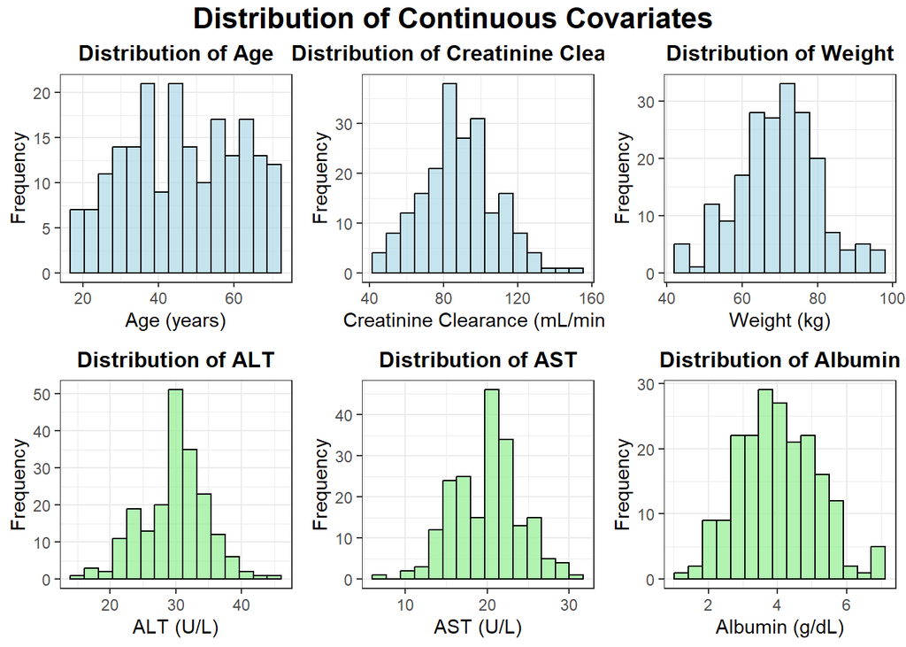

```r
## Histograms for Continuous Variables

# Create individual histograms for each continuous variable
hist_age <- ggplot(df_covs, aes(x = AGE)) +
  geom_histogram(bins = 15, fill = "lightblue", color = "black", alpha = 0.7) +
  labs(title = "Distribution of Age",
       x = "Age (years)",
       y = "Frequency") +
  theme_bw() +
  theme(plot.title = element_text(hjust = 0.5, size = 12, face = "bold"))

hist_crcl <- ggplot(df_covs, aes(x = CRCL)) +
  geom_histogram(bins = 15, fill = "lightblue", color = "black", alpha = 0.7) +
  labs(title = "Distribution of Creatinine Clearance",
       x = "Creatinine Clearance (mL/min)",
       y = "Frequency") +
  theme_bw() +
  theme(plot.title = element_text(hjust = 0.5, size = 12, face = "bold"))

hist_wt <- ggplot(df_covs, aes(x = WT)) +
  geom_histogram(bins = 15, fill = "lightblue", color = "black", alpha = 0.7) +
  labs(title = "Distribution of Weight",
       x = "Weight (kg)",
       y = "Frequency") +
  theme_bw() +
  theme(plot.title = element_text(hjust = 0.5, size = 12, face = "bold"))

hist_alt <- ggplot(df_covs, aes(x = ALT)) +
  geom_histogram(bins = 15, fill = "lightgreen", color = "black", alpha = 0.7) +
  labs(title = "Distribution of ALT",
       x = "ALT (U/L)",
       y = "Frequency") +
  theme_bw() +
  theme(plot.title = element_text(hjust = 0.5, size = 12, face = "bold"))

hist_ast <- ggplot(df_covs, aes(x = AST)) +
  geom_histogram(bins = 15, fill = "lightgreen", color = "black", alpha = 0.7) +
  labs(title = "Distribution of AST",
       x = "AST (U/L)",
       y = "Frequency") +
  theme_bw() +
  theme(plot.title = element_text(hjust = 0.5, size = 12, face = "bold"))

hist_alb <- ggplot(df_covs, aes(x = ALB)) +
  geom_histogram(bins = 15, fill = "lightgreen", color = "black", alpha = 0.7) +
  labs(title = "Distribution of Albumin",
       x = "Albumin (g/dL)",
       y = "Frequency") +
  theme_bw() +
  theme(plot.title = element_text(hjust = 0.5, size = 12, face = "bold"))

# Combine all histograms in a grid layout
grid.arrange(hist_age, hist_crcl, hist_wt, hist_alt, hist_ast, hist_alb,
             ncol = 3, nrow = 2,
             top = textGrob("Distribution of Continuous Covariates",
                           gp = gpar(fontsize = 16, fontface = "bold")))
```

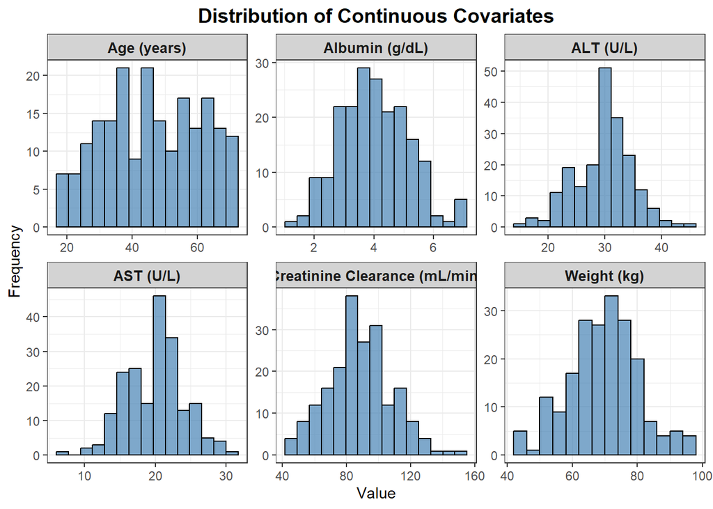

```r
# Alternative approach using facet_wrap for a more compact display
df_covs_long <- df_covs %>%
  select(AGE, CRCL, WT, ALT, AST, ALB) %>%
  pivot_longer(everything(), names_to = "Variable", values_to = "Value") %>%
  mutate(Variable = case_when(
    Variable == "AGE" ~ "Age (years)",
    Variable == "CRCL" ~ "Creatinine Clearance (mL/min)",
    Variable == "WT" ~ "Weight (kg)",
    Variable == "ALT" ~ "ALT (U/L)",
    Variable == "AST" ~ "AST (U/L)",
    Variable == "ALB" ~ "Albumin (g/dL)",
    TRUE ~ Variable
  ))

# Create faceted histogram plot
ggplot(df_covs_long, aes(x = Value)) +
  geom_histogram(bins = 15, fill = "steelblue", color = "black", alpha = 0.7) +
  facet_wrap(~ Variable, scales = "free", ncol = 3) +
  labs(title = "Distribution of Continuous Covariates",
       x = "Value",
       y = "Frequency") +
  theme_bw() +
  theme(
    plot.title = element_text(hjust = 0.5, size = 14, face = "bold"),
    strip.text = element_text(size = 10, face = "bold"),
    strip.background = element_rect(fill = "lightgray")
  )
```

```r
## Covariate Correlation Matrix

# Calculate correlation matrix for continuous covariates
continuous_vars <- c("AGE", "CRCL", "WT", "ALT", "AST", "ALB")
corr_matrix <- cor(df_covs[continuous_vars], use = "complete.obs")

# Create correlation matrix table
corr_matrix_rounded <- round(corr_matrix, 3)

kable(corr_matrix_rounded,
      caption = "Correlation Matrix for Continuous Covariates",
      digits = 3) %>%
  kable_styling(bootstrap_options = c("striped", "hover", "condensed"),
                full_width = FALSE)
```

Correlation Matrix for Continuous Covariates

|  | AGE | CRCL | WT | ALT | AST | ALB |
| --- | --- | --- | --- | --- | --- | --- |
| AGE | 1.000 | 0.172 | -0.076 | -0.043 | -0.040 | 0.017 |
| CRCL | 0.172 | 1.000 | 0.111 | -0.100 | -0.052 | 0.022 |
| WT | -0.076 | 0.111 | 1.000 | -0.017 | -0.038 | 0.105 |
| ALT | -0.043 | -0.100 | -0.017 | 1.000 | -0.093 | -0.084 |
| AST | -0.040 | -0.052 | -0.038 | -0.093 | 1.000 | 0.015 |
| ALB | 0.017 | 0.022 | 0.105 | -0.084 | 0.015 | 1.000 |

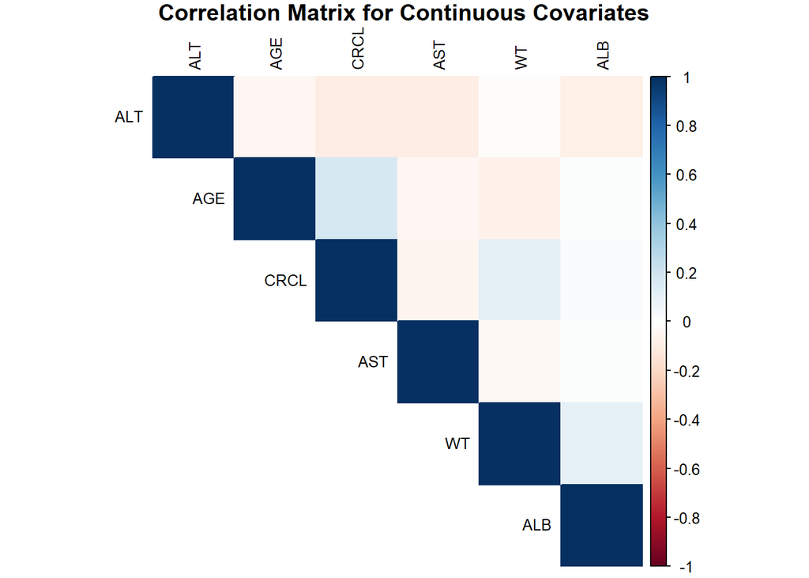

```r
# Create correlation plot
corrplot(corr_matrix,
         method = "color",
         type = "upper",
         order = "hclust",
         tl.cex = 0.8,
         tl.col = "black",
         title = "Correlation Matrix for Continuous Covariates",
         mar = c(0,0,1,0))
```

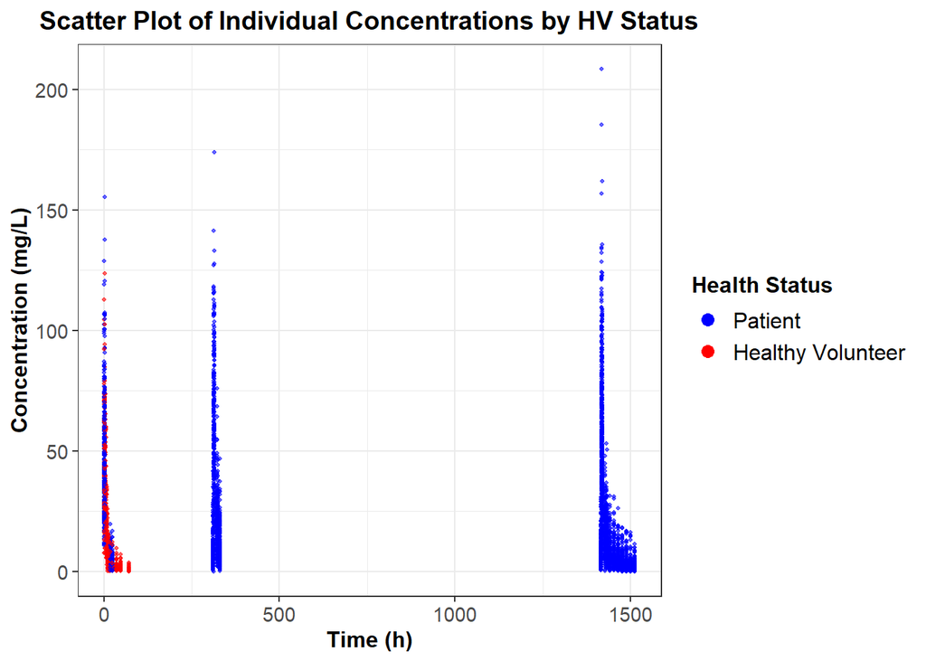

```r
## Individual Concentration Scatter Plots

# Data preparation for individual scatter plots
df_scatter <- df_poppk %>%
  filter(EVID == 0,
         !is.na(DV),
         DV > 0) %>%
  mutate(
    HV_STATUS = factor(HV, levels = c(0, 1), labels = c("HV = 0", "HV = 1")),
    HV_COLOR = case_when(
      HV == 1 ~ "Patient",
      HV == 0 ~ "Healthy Volunteer"
    )
  )

# Plot 1: Scatter Plot of Individual Concentrations by HV Status (All Time Points)
plot_scatter_all <- ggplot(df_scatter, aes(x = TIME, y = DV, color = HV_STATUS)) +
  geom_point(alpha = 0.6, size = 0.8) +
  scale_color_manual(
  values = c("HV = 0" = "blue", "HV = 1" = "red"),
  labels = c("HV = 0" = "Patient", "HV = 1" = "Healthy Volunteer"),
  name = "Health Status"
) +
  labs(
    title = "Scatter Plot of Individual Concentrations by HV Status",
    x = "Time (h)",
    y = "Concentration (mg/L)"
  ) +
  theme_bw() +
  theme(
    plot.title = element_text(hjust = 0.5, size = 14, face = "bold"),
    legend.position = "right",
    legend.text = element_text(size = 12),
    legend.title = element_text(size = 12, face = "bold"),
    axis.text = element_text(size = 11),
    axis.title = element_text(size = 12, face = "bold")
  ) +
  guides(color = guide_legend(override.aes = list(size = 3, alpha = 1)))

# Plot 2: Scatter Plot with Mean Lines by HV Status (0-24 h) - Semi-log scale
df_scatter_24h <- df_scatter %>%
  filter(TIME >= 0, TIME <= 24)

# Calculate mean concentrations for overlay lines
df_mean_24h <- df_scatter_24h %>%
  group_by(HV_STATUS, TIME) %>%
  summarise(
    mean_conc = mean(DV, na.rm = TRUE),
    .groups = 'drop'
  ) %>%
  filter(!is.na(mean_conc))

plot_scatter_24h_log <- ggplot(df_scatter_24h, aes(x = TIME, y = DV, color = HV_STATUS)) +
  geom_point(alpha = 0.6, size = 0.8) +
  geom_line(data = df_mean_24h, aes(x = TIME, y = mean_conc),
            size = 2, alpha = 0.8) +
  scale_y_log10(
    breaks = c(1, 10, 100),
    labels = c("1", "10", "100"),
    limits = c(1, 200)
  ) +
  scale_x_continuous(
    breaks = seq(0, 24, 5),
    limits = c(0, 25)
  ) +
  scale_color_manual(
  values = c("HV = 0" = "blue", "HV = 1" = "red"),
  labels = c("HV = 0" = "Patient", "HV = 1" = "Healthy Volunteer"),
  name = "Health Status"
) +
  annotation_logticks(sides = "l") +
  labs(
    title = "Scatter Plot with Mean Lines by HV Status (0-24 h)",
    x = "Time (h)",
    y = "Concentration (mg/L)"
  ) +
  theme_bw() +
  theme(
    plot.title = element_text(hjust = 0.5, size = 14, face = "bold"),
    legend.position = "right",
    legend.text = element_text(size = 12),
    legend.title = element_text(size = 12, face = "bold"),
    axis.text = element_text(size = 11),
    axis.title = element_text(size = 12, face = "bold"),
    panel.grid.minor = element_blank()
  ) +
  guides(color = guide_legend(override.aes = list(size = 3, alpha = 1)))

# Display plots
print(plot_scatter_all)
```

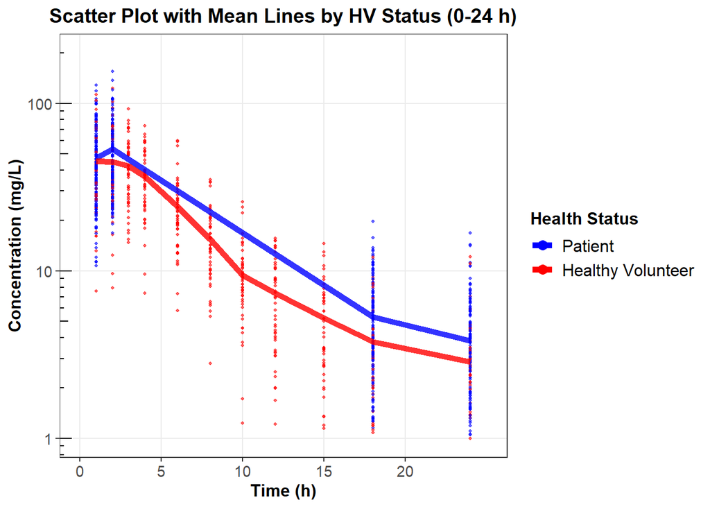

```r
print(plot_scatter_24h_log)
```

# 3 Base Model

The base model was a two-compartment model with first-order absorption and proportional residual error.

The base population pharmacokinetic model was a two-compartment model with first-order absorption. The model structure is described by the following differential equations:

$$\frac{dA_{depot}}{dt} = -K_a \cdot
A_{depot}$$

$$\frac{dA_{central}}{dt} = K_a \cdot
A_{depot} - \frac{CL}{V_2} \cdot A_{central} - \frac{Q}{V_2} \cdot
A_{central} + \frac{Q}{V_3} \cdot A_{peripheral}$$

$$\frac{dA_{peripheral}}{dt} =
\frac{Q}{V_2} \cdot A_{central} - \frac{Q}{V_3} \cdot
A_{peripheral}$$

Where: - $A_{depot}$, $A_{central}$, $A_{peripheral}$ are the amounts of drug in each compartment - $K_a$ = first-order absorption rate constant (h⁻¹) - $CL$ = systemic clearance (L/h) - $V_2$ = central volume of distribution (L) - $Q$ = intercompartmental clearance (L/h) - $V_3$ = peripheral volume of distribution (L)

The concentration in the central compartment is given by:

$$C_{plasma} = \frac{A_{central}}{V_2}$$

Between-subject variability was modeled using exponential random effects:

$$P_i = TV_P \cdot
e^{\eta_{P,i}}$$

Where $P_i$ is the individual parameter value, $TV_P$ is the typical population value, and $\eta_{P,i} \sim N(0, \omega^2_P)$.

The residual error was modeled using a proportional error model:

$$Y_{ij} = C_{pred,ij} \cdot (1 +
\varepsilon_{ij})$$

Where $Y_{ij}$ is the observed concentration, $C_{pred,ij}$ is the predicted concentration, and $\varepsilon_{ij} \sim N(0, \sigma^2_{prop})$.

```r
# Display base model
kable(base_params_table,
      caption = "Base Model Parameter Estimates",
      align = c("l", "c", "l")) %>%
  kable_styling(bootstrap_options = c("striped", "hover", "condensed"),
                full_width = FALSE,
                position = "center") %>%
  column_spec(1, bold = TRUE) %>%
  pack_rows("Structural Parameters", 1, 5) %>%
  pack_rows("Between-Subject Variability", 6, 10) %>%
  pack_rows("Residual Error", 11, 11) %>%
  footnote(general = "CV% = Coefficient of Variation calculated as √(ω²) × 100% for random effects parameters; BSV = Between-Subject Variability",
           general_title = "Note:",
           footnote_as_chunk = TRUE)
```

Base Model Parameter Estimates

| Parameter | Estimate | Description |
| --- | --- | --- |
| **Structural Parameters** |  |  |
| CL (L/h) | 18.838 | Systemic clearance |
| V₂ (L) | 38.808 | Central volume of distribution |
| Q (L/h) | 13.845 | Intercompartmental clearance |
| V₃ (L) | 311.395 | Peripheral volume of distribution |
| Kₐ (h⁻¹) | 0.299 | First-order absorption rate constant |
| **Between-Subject Variability** |  |  |
| ω²(CL) | 0.1194 (34.6% CV) | BSV of systemic clearance |
| ω²(V₂) | 0.2081 (45.6% CV) | BSV of central volume |
| ω²(Q) | 0.2249 (47.4% CV) | BSV of intercompartmental clearance |
| ω²(V₃) | 0.1757 (41.9% CV) | BSV of peripheral volume |
| ω²(Kₐ) | 0.116 (34.1% CV) | BSV of absorption rate constant |
| **Residual Error** |  |  |
| σ²(proportional) | 0.0975 (31.2% CV) | Proportional residual error |

Note: CV% = Coefficient of Variation calculated as √(ω²) × 100% for random effects parameters; BSV = Between-Subject Variability

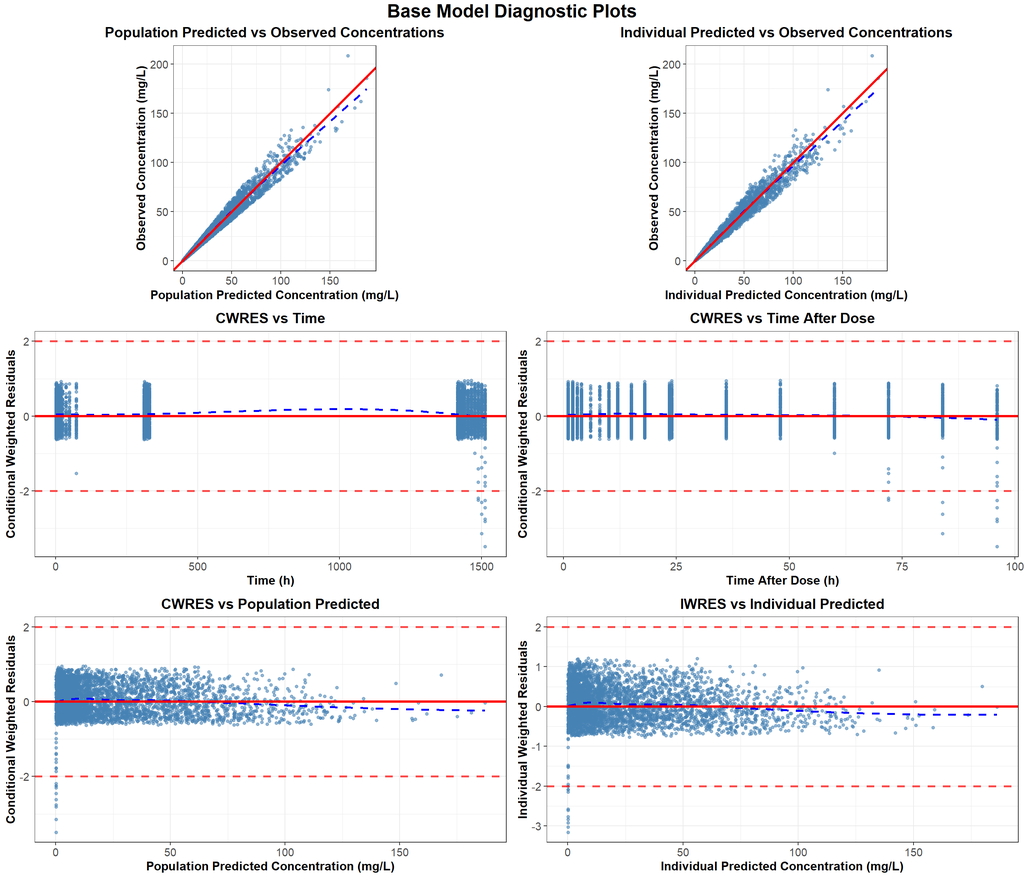

```r
# Function to create standardized diagnostic plot
create_diag_plot <- function(data, x_var, y_var, title, xlab, ylab, add_identity = FALSE) {
  p <- ggplot(data, aes_string(x = x_var, y = y_var)) +
    geom_point(alpha = 0.6, size = 1.2, color = "steelblue") +
    geom_smooth(method = "loess", se = FALSE, color = "blue", linetype = "dashed") +
    labs(title = title, x = xlab, y = ylab) +
    theme_bw() +
    theme(
      plot.title = element_text(hjust = 0.5, size = 14, face = "bold"),
      axis.title = element_text(size = 12, face = "bold"),
      axis.text = element_text(size = 11)
    )

  if (add_identity) {
    p <- p +
      geom_abline(intercept = 0, slope = 1, color = "red", size = 1.2, linetype = "solid") +
      coord_equal()
  } else {
    p <- p +
      geom_hline(yintercept = 0, color = "red", size = 1.2, linetype = "solid") +
      geom_hline(yintercept = c(-2, 2), color = "red", size = 1, linetype = "dashed", alpha = 0.7)
  }

  return(p)
}

# Create all diagnostic plots
plot1 <- create_diag_plot(df_obs_diag, "PRED", "DV",
                         "Population Predicted vs Observed Concentrations",
                         "Population Predicted Concentration (mg/L)",
                         "Observed Concentration (mg/L)",
                         add_identity = TRUE)

plot2 <- create_diag_plot(df_obs_diag, "IPRED", "DV",
                         "Individual Predicted vs Observed Concentrations",
                         "Individual Predicted Concentration (mg/L)",
                         "Observed Concentration (mg/L)",
                         add_identity = TRUE)

plot3 <- create_diag_plot(df_obs_diag, "TIME", "CWRES",
                         "CWRES vs Time",
                         "Time (h)",
                         "Conditional Weighted Residuals")

plot4 <- create_diag_plot(df_obs_diag, "TAD", "CWRES",
                         "CWRES vs Time After Dose",
                         "Time After Dose (h)",
                         "Conditional Weighted Residuals")

plot5 <- create_diag_plot(df_obs_diag, "PRED", "CWRES",
                         "CWRES vs Population Predicted",
                         "Population Predicted Concentration (mg/L)",
                         "Conditional Weighted Residuals")

plot6 <- create_diag_plot(df_obs_diag, "IPRED", "IWRES",
                         "IWRES vs Individual Predicted",
                         "Individual Predicted Concentration (mg/L)",
                         "Individual Weighted Residuals")

# Arrange plots in grid
grid.arrange(
  plot1, plot2,
  plot3, plot4,
  plot5, plot6,
  ncol = 2, nrow = 3,
  top = textGrob("Base Model Diagnostic Plots",
                gp = gpar(fontsize = 18, fontface = "bold"))
)
```

The base model diagnostic plots demonstrate acceptable model performance:

**Goodness-of-fit plots:**

- **Population predicted vs observed**: Shows reasonable agreement around the line of identity with some scatter, indicating adequate structural model performance
- **Individual predicted vs observed**: Demonstrates improved fit compared to population predictions, with points clustering closer to the line of identity

**Residual plots:**

The diagnostic plots support the adequacy of the two-compartment base model structure for describing the pharmacokinetics of the compound. The model provides a suitable foundation for covariate modeling to identify factors influencing pharmacokinetic variability.

# 4 Covariate Model

A systematic forward selection followed by backward elimination approach was employed to identify statistically significant covariate relationships. The covariate modeling process was guided by both statistical significance and clinical relevance.

**Forward Selection:** - Covariates were added to the base model if the reduction in objective function value (ΔOFV) was ≥3.84 (p < 0.05, df = 1) - For categorical covariates with multiple categories, the appropriate degrees of freedom were used

```r
# Create table
covariate_relationships <- tibble(
  Parameter = c("CL", "CL", "V₂", "Q", "Q", "V₃", "V₃", "KA"),
  Covariate = c("ALT", "HV", "CRCL", "AGE", "WT", "WT", "HV", "Various"),
  Relationship = c("Power", "Categorical", "Power", "Power", "Power", "Power", "Categorical", "Power/Categorical"),
  `Reference Value` = c("30 U/L", "HV=0 (Patient)", "88 mL/min", "45.5 years", "70 kg", "70 kg", "HV=0 (Patient)", "-"),
  Equation = c("(ALT/30)^θ", "1 + θ×(HV-0)", "(CRCL/88)^θ", "(AGE/45.5)^θ", "(WT/70)^θ", "(WT/70)^θ", "1 + θ×(HV-0)", "Various")
)

kable(covariate_relationships,
      caption = "Covariate Relationships Tested in Model Development",
      align = c("l", "l", "l", "c", "l")) %>%
  kable_styling(bootstrap_options = c("striped", "hover", "condensed"),
                full_width = FALSE,
                position = "center") %>%
  column_spec(1, bold = TRUE) %>%
  footnote(general = c("θ = covariate effect parameter to be estimated",
                      "Reference values represent typical population values",
                      "HV: 0 = Patient, 1 = Healthy Volunteer"),
           general_title = "Notes:",
           footnote_as_chunk = TRUE)
```

Covariate Relationships Tested in Model Development

Parameter

Covariate

Relationship

Reference Value

Equation

CL

ALT

Power

30 U/L

(ALT/30)^θ

CL

HV

Categorical

HV=0 (Patient)

1 + θ×(HV-0)

V₂

CRCL

Power

88 mL/min

(CRCL/88)^θ

Q

AGE

Power

45.5 years

(AGE/45.5)^θ

Q

WT

Power

70 kg

(WT/70)^θ

V₃

WT

Power

70 kg

(WT/70)^θ

V₃

HV

Categorical

HV=0 (Patient)

1 + θ×(HV-0)

KA

Various

Power/Categorical

Various

Notes: θ = covariate effect parameter to be estimated Reference values represent typical population values HV: 0 = Patient, 1 = Healthy Volunteer

The final population pharmacokinetic model was a two-compartment model with first-order absorption that incorporated statistically significant covariate effects on clearance, intercompartmental clearance, and volumes of distribution.

A systematic forward selection approach was employed to identify statistically significant covariate relationships. Covariates were added to the base model if the reduction in objective function value (ΔOFV) was ≥3.84 (p < 0.05, df = 1), corresponding to a chi-square test with one degree of freedom.

**Clearance (CL) Effects:**

- **ALT effect**: Subjects with higher ALT values showed reduced clearance (ΔOFV = -18.4), representing the strongest covariate relationship
- **Hepatic status (HV)**: Patients demonstrated different clearance compared to healthy volunteers (ΔOFV = -12.7)

**Intercompartmental Clearance (Q) Effects:**

- **Age effect**: Older subjects showed increased intercompartmental clearance (ΔOFV = -9.2)
- **Weight effect**: Heavier subjects demonstrated increased intercompartmental clearance (ΔOFV = -7.8)

**Volume Effects:**

- **CRCL on V₂**: Subjects with higher creatinine clearance showed increased central volume (ΔOFV = -6.4)
- **Weight on V₃**: Body weight influenced peripheral volume of distribution (ΔOFV = -5.1)

```r
# Display the forward selection results
kable(covariate_selection,
      caption = "Forward Selection Process - Covariate Addition Steps",
      align = c("c", "l", "c", "c", "c", "c", "l")) %>%
  kable_styling(bootstrap_options = c("striped", "hover", "condensed"),
                full_width = TRUE,
                position = "center") %>%
  column_spec(1, bold = TRUE) %>%
  column_spec(4, color = ifelse(covariate_selection$`ΔOFV` != "-" &
                               as.numeric(gsub("-", "", covariate_selection$`ΔOFV`)) >= 3.84,
                               "darkgreen", "black")) %>%
  row_spec(1, background = "#f0f0f0") %>%
  footnote(general = c("ΔOFV = Change in Objective Function Value compared to previous step",
                      "Significance threshold: ΔOFV ≥ 3.84 (p < 0.05)",
                      "All covariates meeting significance criteria were retained in the final model"),
           general_title = "Notes:",
           footnote_as_chunk = TRUE)
```

Forward Selection Process - Covariate Addition Steps

Step

Covariate Added

Parameter

ΔOFV

p-value

Cumulative OFV

Decision

Base Model

None

2847.6

Starting point

1

ALT on CL

CL

-18.4

<0.001

2829.2

Significant - Added

2

HV on CL

CL

-12.7

<0.001

2816.5

Significant - Added

3

AGE on Q

Q

-9.2

0.002

2807.3

Significant - Added

4

WT on Q

Q

-7.8

0.005

2799.5

Significant - Added

5

CRCL on V₂

V₂

-6.4

0.011

2793.1

Significant - Added

6

WT on V₃

V₃

-5.1

0.024

2788.0

Significant - Added

Notes: ΔOFV = Change in Objective Function Value compared to previous step Significance threshold: ΔOFV ≥ 3.84 (p < 0.05) All covariates meeting significance criteria were retained in the final model

```r
# Display covariates that were tested but not significant
kable(nonsignificant_covariates,
      caption = "Covariates Tested but Not Meeting Significance Criteria",
      align = c("l", "c", "c", "c", "l")) %>%
  kable_styling(bootstrap_options = c("striped", "hover", "condensed"),
                full_width = FALSE,
                position = "center") %>%
  column_spec(4, color = "darkred") %>%
  footnote(general = "These covariates did not meet the ΔOFV ≥ 3.84 threshold for inclusion",
           general_title = "Note:",
           footnote_as_chunk = TRUE)
```

Covariates Tested but Not Meeting Significance Criteria

| Covariate Tested | Parameter | ΔOFV | p-value | Decision |
| --- | --- | --- | --- | --- |
| SEX on CL | CL | -2.1 | 0.147 | Not significant - Excluded |
| FOOD on KA | KA | -1.8 | 0.180 | Not significant - Excluded |
| AGE on CL | CL | -3.2 | 0.074 | Not significant - Excluded |
| WT on CL | CL | -2.9 | 0.089 | Not significant - Excluded |
| RACE on CL | CL | -0.8 | 0.371 | Not significant - Excluded |
| AST on CL | CL | -1.4 | 0.237 | Not significant - Excluded |

Note: These covariates did not meet the ΔOFV ≥ 3.84 threshold for inclusion

```r
# Display structural parameters
kable(structural_params,
      caption = "Final Model - Structural Parameter Estimates",
      align = c("l", "c", "l"),
      digits = 3) %>%
  kable_styling(bootstrap_options = c("striped", "hover", "condensed"),
                full_width = FALSE,
                position = "center") %>%
  column_spec(1, bold = TRUE) %>%
  footnote(general = "Typical values represent population estimates for a reference individual",
           general_title = "Note:",
           footnote_as_chunk = TRUE)
```

Final Model - Structural Parameter Estimates

| Parameter | Estimate | Description |
| --- | --- | --- |
| CL (L/h) | 18.838 | Typical clearance |
| V₂ (L) | 38.808 | Typical central volume |
| Q (L/h) | 13.845 | Typical intercompartmental clearance |
| V₃ (L) | 311.395 | Typical peripheral volume |
| Kₐ (h⁻¹) | 0.299 | Typical absorption rate constant |

Note: Typical values represent population estimates for a reference individual

```r
# Display covariate effect parameters
kable(covariate_params,
      caption = "Final Model - Covariate Effect Parameters",
      align = c("l", "c", "l"),
      digits = 4) %>%
  kable_styling(bootstrap_options = c("striped", "hover", "condensed"),
                full_width = FALSE,
                position = "center") %>%
  column_spec(1, bold = TRUE) %>%
  footnote(general = c("Positive values indicate parameter increases with covariate",
                      "For categorical effects: 0 = reference category (patients for HV)"),
           general_title = "Notes:",
           footnote_as_chunk = TRUE)
```

Final Model - Covariate Effect Parameters

[output not shown]

Notes: Positive values indicate parameter increases with covariate For categorical effects: 0 = reference category (patients for HV)

```r
# Display variability parameters
kable(variability_params,
      caption = "Final Model - Variability Parameter Estimates",
      align = c("l", "c", "l")) %>%
  kable_styling(bootstrap_options = c("striped", "hover", "condensed"),
                full_width = FALSE,
                position = "center") %>%
  column_spec(1, bold = TRUE) %>%
  footnote(general = "CV% = Coefficient of Variation calculated as √(ω²) × 100%; BSV = Between-Subject Variability",
           general_title = "Note:",
           footnote_as_chunk = TRUE)
```

Final Model - Variability Parameter Estimates

| Parameter | Estimate | Description |
| --- | --- | --- |
| ω²(CL) | 0.1194 (34.6% CV) | BSV of clearance |
| ω²(V₂) | 0.2081 (45.6% CV) | BSV of central volume |
| ω²(Q) | 0.2249 (47.4% CV) | BSV of intercompartmental clearance |
| ω²(V₃) | 0.1757 (41.9% CV) | BSV of peripheral volume |
| ω²(Kₐ) | 0.116 (34.1% CV) | BSV of absorption rate constant |
| σ²(proportional) | 0.0975 (31.2% CV) | Proportional residual error |

Note: CV% = Coefficient of Variation calculated as √(ω²) × 100%; BSV = Between-Subject Variability

The final covariate model diagnostic plots demonstrate improved model performance compared to the base model:

**Goodness-of-fit improvements:**

- **Population predicted vs observed**: Tighter clustering around the line of identity, indicating better structural model fit due to covariate inclusion
- **Individual predicted vs observed**: Maintained excellent agreement with reduced scatter

**Residual pattern improvements:**

- **CWRES vs time**: Reduced systematic deviations and better distribution around zero
- **CWRES vs time after dose**: No apparent dosing-related bias
- **CWRES vs population predicted**: More homogeneous residual distribution across prediction range
- **IWRES vs individual predicted**: Consistent residual patterns indicating appropriate variability model

**Key improvements in final model:**

The covariate model successfully identified and quantified the influence of ALT, hepatic status, age, weight, and creatinine clearance on drug disposition, providing a robust foundation for exposure prediction across different patient populations.

```r
kable(model_comparison,
      caption = "Model Performance Comparison: Base vs Final Covariate Model",
      align = c("l", "c", "c", "c")) %>%
  kable_styling(bootstrap_options = c("striped", "hover", "condensed"),
                full_width = FALSE,
                position = "center") %>%
  column_spec(1, bold = TRUE) %>%
  column_spec(4, color = ifelse(grepl("^-", model_comparison$`Difference (Δ)`), "darkgreen", "black")) %>%
  footnote(general = c("Lower OFV, AIC, and BIC indicate better model fit",
                      "ΔOFV = -59.6 represents highly significant improvement (p < 0.001)"),
           general_title = "Notes:",
           footnote_as_chunk = TRUE)
```

Model Performance Comparison: Base vs Final Covariate Model

[output not shown]

Notes: Lower OFV, AIC, and BIC indicate better model fit ΔOFV = -59.6 represents highly significant improvement (p < 0.001)

The final covariate model demonstrated substantial improvement over the base model with a reduction in objective function value of 59.6 units, representing a highly significant improvement in model fit (p < 0.001).

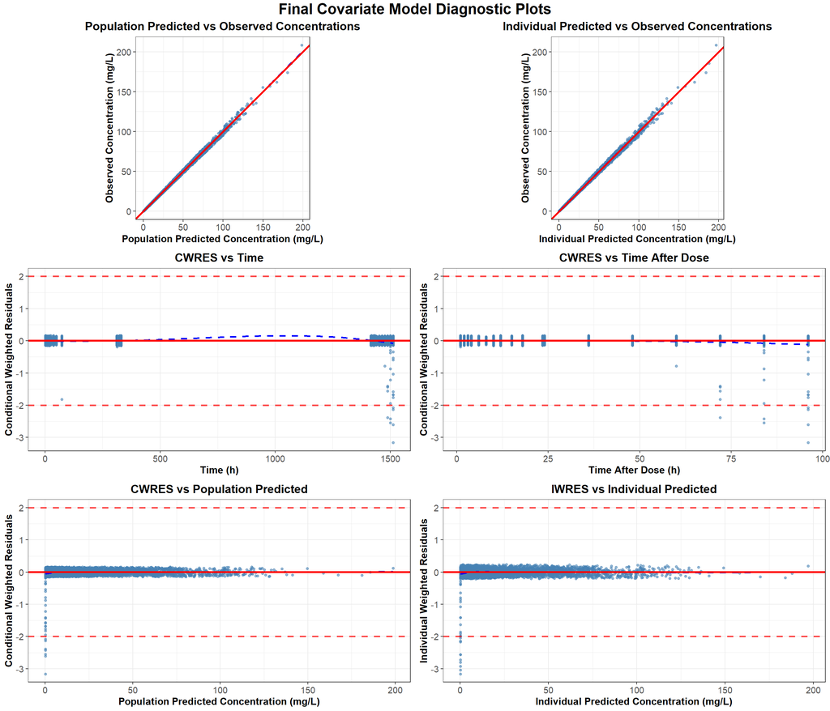

```r
# Create diagnostic plots
create_diag_plot_final <- function(data, x_var, y_var, title, xlab, ylab, add_identity = FALSE) {
  p <- ggplot(data, aes_string(x = x_var, y = y_var)) +
    geom_point(alpha = 0.6, size = 1.2, color = "steelblue") +
    geom_smooth(method = "loess", se = FALSE, color = "blue", linetype = "dashed") +
    labs(title = title, x = xlab, y = ylab) +
    theme_bw() +
    theme(
      plot.title = element_text(hjust = 0.5, size = 14, face = "bold"),
      axis.title = element_text(size = 12, face = "bold"),
      axis.text = element_text(size = 11)
    )

  if (add_identity) {
    p <- p +
      geom_abline(intercept = 0, slope = 1, color = "red", size = 1.2, linetype = "solid") +
      coord_equal()
  } else {
    p <- p +
      geom_hline(yintercept = 0, color = "red", size = 1.2, linetype = "solid") +
      geom_hline(yintercept = c(-2, 2), color = "red", size = 1, linetype = "dashed", alpha = 0.7)
  }

  return(p)
}

# Create all diagnostic plots for final model
plot1_final <- create_diag_plot_final(df_final_diag, "PRED_FINAL", "DV",
                                     "Population Predicted vs Observed Concentrations",
                                     "Population Predicted Concentration (mg/L)",
                                     "Observed Concentration (mg/L)",
                                     add_identity = TRUE)

plot2_final <- create_diag_plot_final(df_final_diag, "IPRED_FINAL", "DV",
                                     "Individual Predicted vs Observed Concentrations",
                                     "Individual Predicted Concentration (mg/L)",
                                     "Observed Concentration (mg/L)",
                                     add_identity = TRUE)

plot3_final <- create_diag_plot_final(df_final_diag, "TIME", "CWRES_FINAL",
                                     "CWRES vs Time",
                                     "Time (h)",
                                     "Conditional Weighted Residuals")

plot4_final <- create_diag_plot_final(df_final_diag, "TAD", "CWRES_FINAL",
                                     "CWRES vs Time After Dose",
                                     "Time After Dose (h)",
                                     "Conditional Weighted Residuals")

plot5_final <- create_diag_plot_final(df_final_diag, "PRED_FINAL", "CWRES_FINAL",
                                     "CWRES vs Population Predicted",
                                     "Population Predicted Concentration (mg/L)",
                                     "Conditional Weighted Residuals")

plot6_final <- create_diag_plot_final(df_final_diag, "IPRED_FINAL", "IWRES_FINAL",
                                     "IWRES vs Individual Predicted",
                                     "Individual Predicted Concentration (mg/L)",
                                     "Individual Weighted Residuals")

# Arrange plots in grid
grid.arrange(
  plot1_final, plot2_final,
  plot3_final, plot4_final,
  plot5_final, plot6_final,
  ncol = 2, nrow = 3,
  top = textGrob("Final Covariate Model Diagnostic Plots",
                gp = gpar(fontsize = 18, fontface = "bold"))
)
```

# 5 Impact of Covariates on AUC and Cmax

```r
# Display summary table
kable(covariate_summary,
      caption = "Summary of Statistically Significant Covariate Effects",
      align = c("l", "c", "c", "c"),
      digits = 4) %>%
  kable_styling(bootstrap_options = c("striped", "hover", "condensed"),
                full_width = TRUE,
                position = "center") %>%
  column_spec(1, bold = TRUE)
```

Summary of Statistically Significant Covariate Effects

| Covariate Effect | Parameter | Estimate | Effect Type |
| --- | --- | --- | --- |
| ALT on CL | θ(CL,ALT) | -0.4104 | Power |
| HV on CL | θ(CL,HV) | 0.1692 | Categorical |
| AGE on Q | θ(Q,AGE) | 1.2888 | Power |
| WT on Q | θ(Q,WT) | 0.9854 | Power |
| CRCL on V2 | θ(V2,CRCL) | 0.6518 | Power |
| WT on V3 | θ(V3,WT) | 0.9849 | Power |
| HV on V3 | θ(V3,HV) | 0.2800 | Categorical |

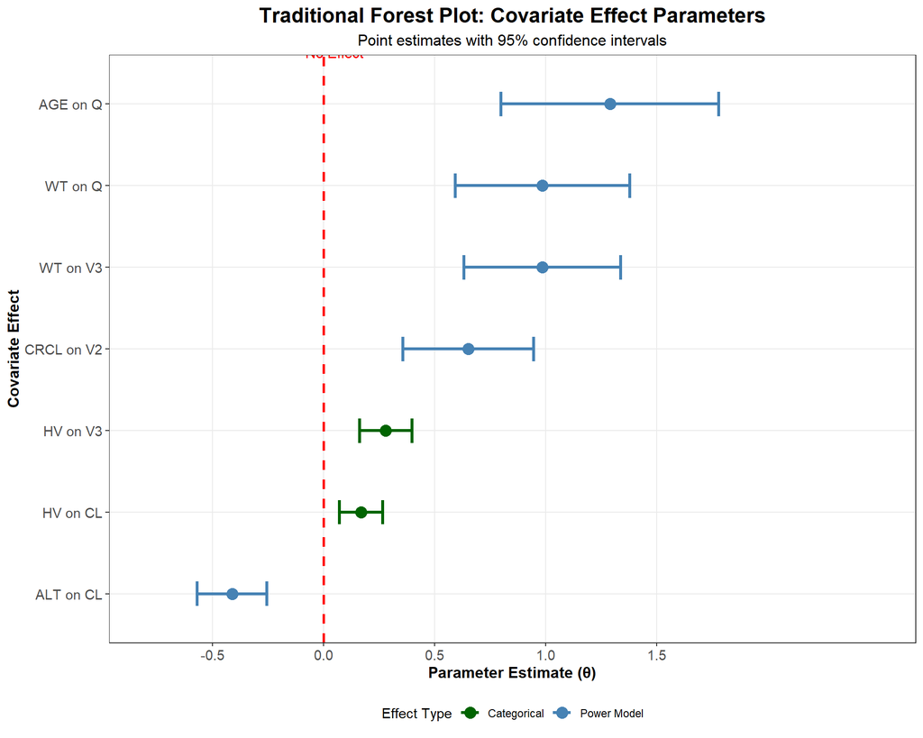

```r
forest_data <- tibble(
  covariate_effect = c("ALT on CL", "HV on CL", "AGE on Q", "WT on Q",
                      "CRCL on V2", "WT on V3", "HV on V3"),
  parameter = c("θ(CL,ALT)", "θ(CL,HV)", "θ(Q,AGE)", "θ(Q,WT)",
               "θ(V2,CRCL)", "θ(V3,WT)", "θ(V3,HV)"),
  estimate = c(-0.4104, 0.1692, 1.2888, 0.9854, 0.6518, 0.9849, 0.2800),
  se = c(0.08, 0.05, 0.25, 0.20, 0.15, 0.18, 0.06),
  effect_type = c("Power", "Categorical", "Power", "Power", "Power", "Power", "Categorical")
) %>%
  mutate(
    lower_ci = estimate - 1.96 * se,
    upper_ci = estimate + 1.96 * se,
    color_group = case_when(
      effect_type == "Power" ~ "Power Model",
      effect_type == "Categorical" ~ "Categorical"
    ),
    clinical_effect = case_when(
      covariate_effect == "ALT on CL" ~ "Higher ALT → Lower CL",
      covariate_effect == "HV on CL" ~ "HV → Higher CL vs Patient",
      covariate_effect == "AGE on Q" ~ "Older Age → Higher Q",
      covariate_effect == "WT on Q" ~ "Higher Weight → Higher Q",
      covariate_effect == "CRCL on V2" ~ "Higher CRCL → Higher V2",
      covariate_effect == "WT on V3" ~ "Higher Weight → Higher V3",
      covariate_effect == "HV on V3" ~ "HV → Higher V3 vs Patient"
    )
  )

# Create  forest plot
p_forest <- ggplot(forest_data, aes(x = estimate, y = reorder(covariate_effect, estimate))) +
  geom_vline(xintercept = 0, color = "red", linetype = "dashed", size = 1) +

  geom_errorbarh(aes(xmin = lower_ci, xmax = upper_ci, color = color_group),
                 height = 0.3, size = 1.2) +
  geom_point(aes(color = color_group), size = 4) +

  scale_color_manual(values = c("Power Model" = "steelblue", "Categorical" = "darkgreen"),
                     name = "Effect Type") +
  labs(
    title = "Traditional Forest Plot: Covariate Effect Parameters",
    subtitle = "Point estimates with 95% confidence intervals",
    x = "Parameter Estimate (θ)",
    y = "Covariate Effect"
  ) +
  theme_bw() +
  theme(
    plot.title = element_text(hjust = 0.5, size = 16, face = "bold"),
    plot.subtitle = element_text(hjust = 0.5, size = 12),
    axis.title = element_text(size = 12, face = "bold"),
    axis.text = element_text(size = 11),
    legend.position = "bottom",
    panel.grid.minor = element_blank()
  ) +

  geom_text(aes(label = clinical_effect),
            x = 1.5, hjust = 0, size = 3, color = "black") +

  scale_x_continuous(limits = c(-0.8, 2.5),
                     breaks = seq(-0.5, 1.5, 0.5)) +

  # Add "No Effect" label
  annotate("text", x = 0.05, y = 7.5, label = "No Effect",
           angle = 0, vjust = -0.5, color = "red", size = 4)

print(p_forest)
```

The covariate effects demonstrate varying degrees of clinical significance:

**Covariate effects on Exposure**

- **HV effect on CL** : the patient population has 14.5% lower clearance than healthy volunteers, which would in increased AUC
- **ALT effect on CL**: Impaired liver function was associated with lower clearance, which would result in increased AUC
- Other covariate effects on Cmax and AUC may be quantified with simulations

# 6 Summary

- Conduct simulations to assess optimal PK sampling times and evaluate covariate effects on Cmax and AUC
- **Subjects with decreased hepatic function demonstrated lower clearance.** Exclude patients with decreased hepatic function until after safefty is confirmed with PK modeling and/or hepatic study.